# Matching project

Nadir Nibras

January 30, 2019

# Matching project for evaluating effects of treatment dosage

clear workspace variables clear command window (same as ctrl+L. ) close all plots

```r
rm(list = ls());
cat("\014")
```

```r
graphics.off()
```

```r
library(tidyverse)
library(Matching)
library(cobalt)
library(onehot)
library(pander)
```

variables

```r
Lthreshold= 15
Hthreshold= 30
```

### Read files

```r
setwd("C:/Users/nadir/Desktop/Matching/BKN 599 Advanced Data Analysis")
evalData=read.csv("00042_evalDataset_notext.csv")
patChar= read.csv("PatientCharacteristics_withDose.csv")
rawd= read.csv("Raw Data_Included Subjects Only_mod.csv", sep="\t") # neural values
```

### Coding all -99 values as missing data

```r
evalData[evalData == -99] <- NA;
patChar[(patChar ==-99)|(patChar ==-7)|(patChar ==-8)|(patChar ==-9)] <- NA;
rawd[rawd ==-1] <- NA;
```

#### Setting key for merging datasets

```r
patChar=rename(patChar, pid= PID )
rawd=rename(rawd, pid= Study_id )
```

### Examining Matchnig features from EvalData visit 1 scores

```r
# evalData.cnames= data.frame(colnames(evalData))
# pc.cnames= data.frame(colnames(patChar))
# rawd.cnames= data.frame(colnames(rawd))
# evalData1=evalData1[complete.cases(evalData1),]
# evalD.correlations= data.frame(cor(evalData1[-c(1,2)]))
```

# Processing Raw/Neural Data set

```r
rawd$multlesions= as.integer(rawd$A2x!="\\N")
rawd= rawd[c(1,13,32, 107, 130, 143)];
rawd$old_stroke= as.integer(as.factor(rawd$old_stroke))-1
rawd$leukoaraiosis= as.integer(as.factor(rawd$leukoaraiosis))-1
rawd$A1EstVol= log2(rawd$A1EstVol+1)
rawd=rename(rawd, log2.A1EstVol= A1EstVol ) #renaming column name
```

# Remove sparse features/features with no use

```r
evalData = evalData[c(5,6,120,128,204,246,260,277,367,368,371,372)]
# Note: Leaving out FAS scores because many (18) missed values for visit 1 stats
patChar= patChar[c(3,6,7,12,15:21,27,29:32)]

#removing Treatment type
patChar= patChar[-c(3)]
```

### Merge data

```r
dataMerged= merge(evalData,patChar)
dataMerged= merge(dataMerged, rawd)
```

### Extract visit datas

```r
dataVisit1= subset(dataMerged, visitnum==1)
dataVisit2= subset(dataMerged, visitnum==2)
rm(dataMerged)
```

### Removing subjects with missing values

```r
dataVisit1= dataVisit1[complete.cases(dataVisit1),]
dataVisit2= dataVisit2[complete.cases(dataVisit2),]
```

```r
temp1= data.frame(dataVisit1$pid);
temp2= data.frame(dataVisit2$pid);

names(temp1)[1]<-paste("pid");   #renaming column name to "pid"
names(temp2)[1]<-paste("pid");   #renaming column name to "pid"

temp= merge(temp1,temp2)

dataVisit1= merge(temp,dataVisit1)
dataVisit2= merge(temp,dataVisit2)

rm(temp,temp1,temp2)
```

### Creating dataset for matching

```r
data12= dataVisit1
```

### One hot encoding

```r
# Site code
sitecode=data.frame(as.factor(data12$siteCode))
names(sitecode)[1]<-paste("Site.code")
data12 = cbind(data12,data.frame(predict(onehot(sitecode),sitecode)))

# Predominant
predominant=data.frame(as.factor(data12$predominant))
names(predominant)[1]<-paste("predominant")
data12 = cbind(data12,data.frame(predict(onehot(predominant,  max_levels = 13),predominant)))

# Ethnicity
data12$hispanic.latino= ifelse(data12$DEMOEthnicity==1, 1, 0)
data12$nonhispanic.latino= ifelse(data12$DEMOEthnicity==2, 1, 0)

# Race
data12$race.indeginous= ifelse(data12$DEMORace==1, 1, 0)
data12$race.asian= ifelse(data12$DEMORace==2, 1, 0)
data12$race.pacific= ifelse(data12$DEMORace==3, 1, 0)
data12$race.africanam= ifelse(data12$DEMORace== 4, 1, 0)
data12$race.caucasian= ifelse(data12$DEMORace== 5, 1, 0)
data12$race.other= ifelse(data12$DEMORace== 6, 1, 0)

# Education
data12$edu.underHS= ifelse(data12$DEMOedu==1, 1, 0)
data12$edu.someHS= ifelse(data12$DEMOedu==2, 1, 0)
data12$edu.finishHS= ifelse(data12$DEMOedu==3, 1, 0)
data12$edu.someCollege= ifelse(data12$DEMOedu== 4, 1, 0)
data12$edu.finishCollege= ifelse(data12$DEMOedu== 5, 1, 0)
data12$edu.finishMasters= ifelse(data12$DEMOedu== 6, 1, 0)
data12$edu.finishPHD= ifelse(data12$DEMOedu== 7, 1, 0)

# Stroke type
data12$stroke.loc.RightH= ifelse(data12$CSstrkloc==1, 1, 0)
data12$stroke.loc.LeftH= ifelse(data12$CSstrkloc==2, 1, 0)
data12$stroke.loc.cerebellar= ifelse(data12$CSstrkloc==3, 1, 0)
data12$stroke.loc.brainstem= ifelse(data12$CSstrkloc== 4, 1, 0)

# Stroke location
data12$stroke.loc.RightH= ifelse(data12$CSstrkloc==1, 1, 0)
data12$stroke.loc.LeftH= ifelse(data12$CSstrkloc==2, 1, 0)
data12$stroke.loc.cerebellar= ifelse(data12$CSstrkloc==3, 1, 0)
data12$stroke.loc.brainstem= ifelse(data12$CSstrkloc== 4, 1, 0)

#Remove extra columns and extra variables
data12$DEMOedu=NULL
data12$DEMOEthnicity=NULL
data12$DEMORace=NULL
data12$CSstrkloc=NULL
data12$CSstrktype=NULL
data12$predominant=NULL
data12$siteCode=NULL
data12$visitnum= NULL
rm(sitecode,predominant)
```

### Changing table to numeric

```r
for (i in 2:ncol(data12)){
  data12[c(i)]= as.numeric(unlist(data12[c(i)]))
}
```

### Creating recovery parameters from differences in visit2 and vist 1

```r
data12$sishand_recovery= dataVisit2$SIS_hand-dataVisit1$SIS_hand
data12$fugm_recovery= dataVisit2$ufugm-dataVisit1$ufugm
data12$logwmftMA_recovery= dataVisit2$log_mean_time_MA_PA-dataVisit1$log_mean_time_MA_PA
```

# Note: Low Dose group is the treated group, and High Dose is the control group for matching

### creating binary variable indicating whether subject belongs in Low Dose or High Dose group

```r
data12$treat=ifelse(data12$dose_hours<=27, 1, 0)
```

### This line removes all subjects between 16-29 hours of dosage

```r
data12=data12[data12$dose_hours>=Hthreshold | data12$dose_hours<=Lthreshold,]
```

### Creating 2 dataframes separatomg low dose and high dose (not used)

```r
highdosegroup= subset(data12, treat==0)
lowdosegroup= subset(data12, treat==1)
```

### Propensity Score Matching code starts here

creates a marrix from columns/features

```r
X= data.matrix(data12[,c(2:11,13:62)])
```

### Calculating the propensity score

Generalized linear models are fit using the glm( ) function. treat ~ X means treat is the response of all other variables treat is a binary factor and Family objects provide a convenient way to specify the details of the models used by functions such as glm family= binomial() specifies that Logistic Regression is to be performed

```r
model <- glm(treat ~ X,    family = binomial(), data = data12 )
```

### Matching and estimating effects of causality using “Match” package

“Match” implements a variety of algorithms for multivariate matching including propensity score, Mahalanobis and inverse variance matching. The function is intended to be used in conjunction with the MatchBalance function which determines the extent to which Match has been able to achieve covariate balance

-replace = TRUE Matching with replacement

#### Matching using ATT

```r
rr1 =Match(Tr= data12$treat, X= model$fitted.values, estimand = "ATT",
           M=1, ties= FALSE, replace= TRUE)
```

### Exploring propensity score distributions

```r
data12$propensity.score= model$fitted.values

library(gridExtra)
```

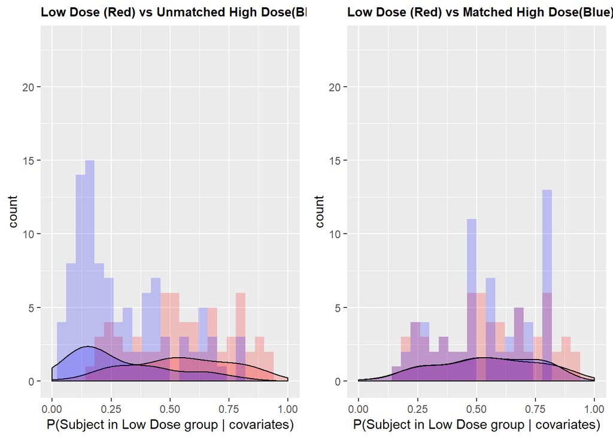

```r
plot1<-ggplot(data12, aes(propensity.score)) +
  geom_histogram(data = subset(data12,treat == '1'),fill = "red", alpha = 0.2,binwidth=0.04)+
  geom_histogram(data = subset(data12,treat == '0'),fill = "blue", alpha = 0.2,binwidth=0.04)+
  geom_density(data = subset(data12,treat == '1'),fill = "red", alpha = 0.2)+
  geom_density(data = subset(data12,treat == '0'),fill = "blue", alpha = 0.2)+
  ggtitle("Low Dose (Red) vs Unmatched High Dose(Blue)")+
  xlab("P(Subject in Low Dose group | covariates)")+
  xlim(c(0,1))+
  ylim(c(0,23))+
  theme(plot.title = element_text(size = 10, face = "bold"))

plot2<-ggplot(data12, aes(propensity.score)) +
  geom_histogram(data= data12[rr1$index.treated,],fill = "red", alpha = 0.2,binwidth=0.04)+
  geom_histogram(data= data12[rr1$index.control,],fill = "blue", alpha = 0.2,binwidth=0.04)+
  geom_density(data = data12[rr1$index.treated,],fill = "red", alpha = 0.2)+
  geom_density(data = data12[rr1$index.control,],fill = "blue", alpha = 0.2)+
  ggtitle("Low Dose (Red) vs Matched High Dose(Blue)")+
  xlab("P(Subject in Low Dose group | covariates)")+
  xlim(c(0,1))+
  ylim(c(0,23))+
  theme(plot.title = element_text(size = 10, face = "bold"))

grid.arrange(plot1, plot2, ncol=2)
```

#### Checking unique values of matched subjects

```r
length(unique(rr1$index.treated))
```

```
## [1] 66
```

```r
length(unique(rr1$index.control))
```

```
## [1] 32
```

### Assessing balance

“MatchBalance” is used to determine if Match was successful in achieving balance on the observed covariates.

-treat~SIS_hand+ … This formula does not estimate any model. The formula is simply an efficient way to use the R modeling language to list the variables we wish to obtain univariate balance statistics for. The dependent variable in the formula is usually the treatment indicator

```r
MatchBalance(treat~ ave_CAHM + SIS_hand + ufugm + NIHtot + log_mean_time_MA_PA +
               log_mean_time_LA_PA + EQ_index +grip_MA +grip_LA +RNLIadj+

               CSgender+ concordance +  onset_to_rand + CStpa + age_at_rand +
               FCtotalOT+ log2.A1EstVol+old_stroke +DEMOsmoke+ leukoaraiosis+ multlesions+

               Site.code.1+ Site.code.2+ Site.code.3+Site.code.4+
               Site.code.5+ Site.code.6+ Site.code.7+ predominant.AC1+ predominant.AC2 +
               predominant.AC3+ predominant.ACH +predominant.basilar+ predominant.IB+
               predominant.LS+ predominant.MC2+ predominant.MC3+ predominant.MC5+ predominant.PCA+
               predominant.vertebral +predominant.THP+ hispanic.latino+nonhispanic.latino+
               race.indeginous+ race.asian+ race.pacific+ race.africanam+ race.caucasian +
               race.other+ edu.underHS+ edu.someHS +edu.finishHS +edu.someCollege +
               edu.finishCollege +edu.finishMasters +edu.finishPHD+stroke.loc.RightH+
               stroke.loc.LeftH +stroke.loc.cerebellar +stroke.loc.brainstem,

             match.out= rr1, nboots=1000,data= data12)
```

```
##
## ***** (V1) ave_CAHM *****
##                        Before Matching        After Matching
## mean treatment........     45.479             45.479
## mean control..........     47.275              52.31
## std mean diff.........    -7.9062             -30.07
##
## mean raw eQQ diff.....     4.4857             9.4622
## med  raw eQQ diff.....          4              8.368
## max  raw eQQ diff.....         12              24.75
##
## mean eCDF diff........   0.052639            0.10065
## med  eCDF diff........   0.042424           0.075758
## max  eCDF diff........    0.15022            0.28788
##
## var ratio (Tr/Co).....    0.86576            0.69343
## T-test p-value........    0.62565            0.12266
## KS Bootstrap p-value..      0.261              0.009
## KS Naive p-value......    0.31985           0.008425
## KS Statistic..........    0.15022            0.28788
##
##
## ***** (V2) SIS_hand *****
##                        Before Matching        After Matching
## mean treatment........      30.53              30.53
## mean control..........     34.571               37.5
## std mean diff.........    -18.731            -32.304
##
## mean raw eQQ diff.....     5.2273             8.7879
## med  raw eQQ diff.....          5                  5
## max  raw eQQ diff.....         15                 25
##
## mean eCDF diff........    0.05573           0.091707
## med  eCDF diff........   0.051948           0.090909
## max  eCDF diff........    0.10303            0.27273
##
## var ratio (Tr/Co).....    0.73011            0.67821
## T-test p-value........    0.26639           0.089352
## KS Bootstrap p-value..      0.503              0.006
## KS Naive p-value......    0.78283           0.014758
```

[output cut: 1073 more lines]

```
## max  raw eQQ diff.....          0                  1
##
## mean eCDF diff........  0.0030303           0.030303
## med  eCDF diff........  0.0030303           0.030303
## max  eCDF diff........  0.0060606           0.060606
##
## var ratio (Tr/Co).....    0.92022                Inf
## T-test p-value........     0.8748           0.043062
##
##
## Before Matching Minimum p.value: 0.01
## Variable Name(s): NIHtot  Number(s): 4
##
## After Matching Minimum p.value: 0.0019539
## Variable Name(s): nonhispanic.latino race.other  Number(s): 43 49
```

## Cobalt package for assessing balance

```r
set.cobalt.options(continuous= "std",binary= "std")

(bal.tab(rr1, treat~ ave_CAHM + SIS_hand + ufugm + NIHtot + log_mean_time_MA_PA +
               log_mean_time_LA_PA + EQ_index +grip_MA +grip_LA +RNLIadj+

               CSgender+ concordance +  onset_to_rand + CStpa + age_at_rand +
               FCtotalOT+ log2.A1EstVol+old_stroke +DEMOsmoke+ leukoaraiosis+ multlesions+

               Site.code.1+ Site.code.2+ Site.code.3+Site.code.4+
               Site.code.5+ Site.code.6+ Site.code.7+ predominant.AC1+ predominant.AC2 +
               predominant.AC3+ predominant.ACH +predominant.basilar+ predominant.IB+
               predominant.LS+ predominant.MC2+ predominant.MC3+ predominant.MC5+ predominant.PCA+
               predominant.vertebral +predominant.THP+ hispanic.latino+nonhispanic.latino+
               race.indeginous+ race.asian+ race.pacific+ race.africanam+ race.caucasian +
               race.other+ edu.underHS+ edu.someHS +edu.finishHS +edu.someCollege +
               edu.finishCollege +edu.finishMasters +edu.finishPHD+stroke.loc.RightH+
               stroke.loc.LeftH +stroke.loc.cerebellar +stroke.loc.brainstem+ propensity.score,

         disp.v.ratio = TRUE, data = data12,abs= TRUE, m.threshold =0.1))
```

```
## Balance Measures
##                          Type Diff.Adj        M.Threshold V.Ratio.Adj
## ave_CAHM              Contin.   0.2531 Not Balanced, >0.1      1.3070
## SIS_hand              Contin.   0.3125 Not Balanced, >0.1      1.6537
## ufugm                 Contin.   0.0247     Balanced, <0.1      1.0528
## NIHtot                Contin.   0.0335     Balanced, <0.1      1.2065
## log_mean_time_MA_PA   Contin.   0.0287     Balanced, <0.1      1.0016
## log_mean_time_LA_PA   Contin.   0.0675     Balanced, <0.1      1.2973
## EQ_index              Contin.   0.1016 Not Balanced, >0.1      1.4512
## grip_MA               Contin.   0.0397     Balanced, <0.1      1.0135
## grip_LA               Contin.   0.0627     Balanced, <0.1      1.1472
## RNLIadj               Contin.   0.0299     Balanced, <0.1      1.0151
## CSgender_2             Binary   0.0403     Balanced, <0.1
## concordance_2          Binary   0.0608     Balanced, <0.1
## onset_to_rand         Contin.   0.2025 Not Balanced, >0.1      1.3161
## CStpa                  Binary   0.1314 Not Balanced, >0.1
## age_at_rand           Contin.   0.0690     Balanced, <0.1      1.0449
## FCtotalOT             Contin.   0.2744 Not Balanced, >0.1      1.0635
## log2.A1EstVol         Contin.   0.1173 Not Balanced, >0.1      1.0063
## old_stroke             Binary   0.0520     Balanced, <0.1
## DEMOsmoke              Binary   0.1677 Not Balanced, >0.1
## leukoaraiosis          Binary   0.0218     Balanced, <0.1
## multlesions            Binary   0.0840     Balanced, <0.1
## Site.code.1            Binary   0.4952 Not Balanced, >0.1
## Site.code.2            Binary   0.1403 Not Balanced, >0.1
## Site.code.3            Binary   0.1203 Not Balanced, >0.1
## Site.code.4            Binary   0.1046 Not Balanced, >0.1
## Site.code.5            Binary   0.1794 Not Balanced, >0.1
## Site.code.6            Binary   0.1743 Not Balanced, >0.1
## Site.code.7            Binary   0.1754 Not Balanced, >0.1
## predominant.AC1        Binary   0.0000     Balanced, <0.1
## predominant.AC2        Binary   0.1231 Not Balanced, >0.1
## predominant.ACH        Binary   0.0406     Balanced, <0.1
## predominant.basilar    Binary   0.0559     Balanced, <0.1
## predominant.IB         Binary   0.1203 Not Balanced, >0.1
## predominant.LS         Binary   0.1754 Not Balanced, >0.1
## predominant.MC2        Binary   0.1022 Not Balanced, >0.1
## predominant.MC3        Binary   0.0488     Balanced, <0.1
## predominant.MC5        Binary   0.1231 Not Balanced, >0.1
## predominant.PCA        Binary
```

[output cut: 23 more lines]

```
## Balance tally for mean differences
##                    count
## Balanced, <0.1        24
## Not Balanced, >0.1    34
##
## Variable with the greatest mean difference
##          Variable Diff.Adj        M.Threshold
##  propensity.score   0.5412 Not Balanced, >0.1
##
## Sample sizes
##                      Control Treated
## All                      105      66
## Matched                   99      66
## Matched (Unweighted)      60      66
## Unmatched                 45       0
```

### Looking at distributions of all continuous variables

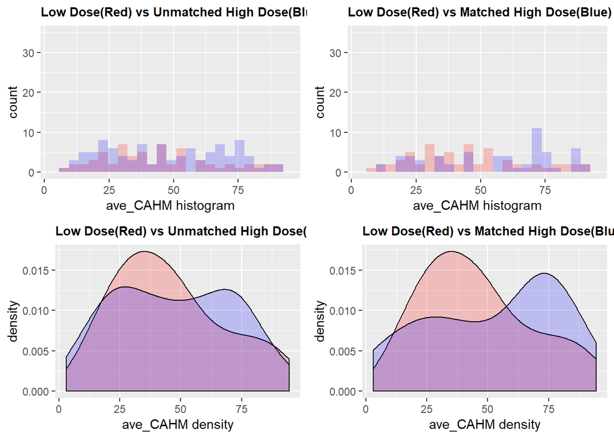

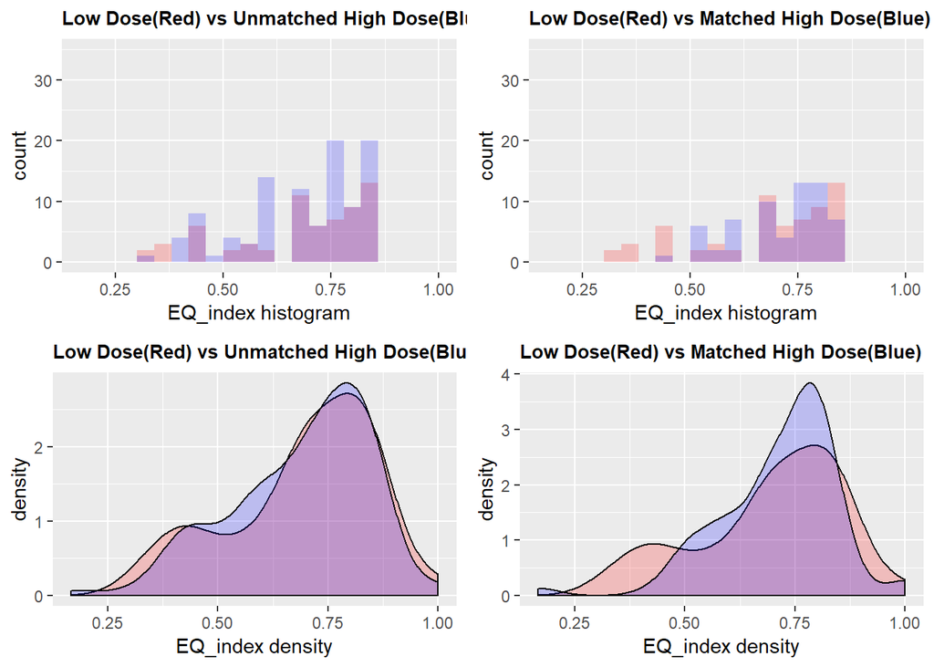

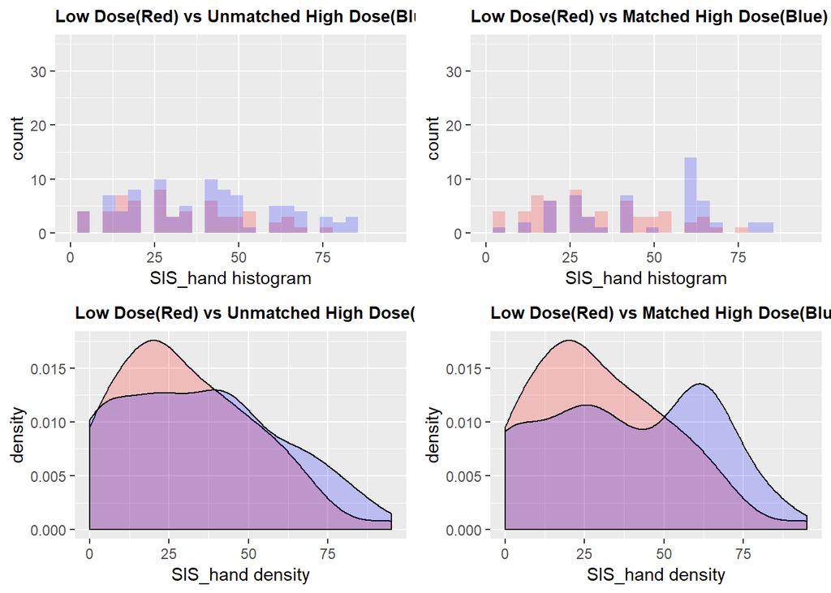

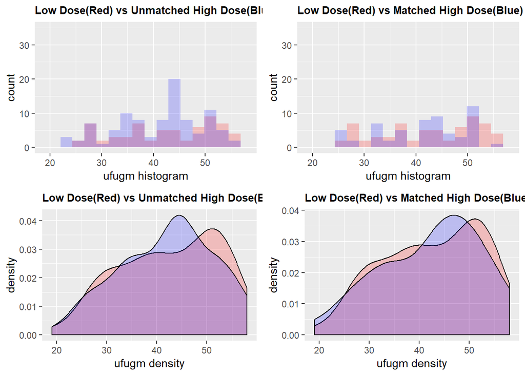

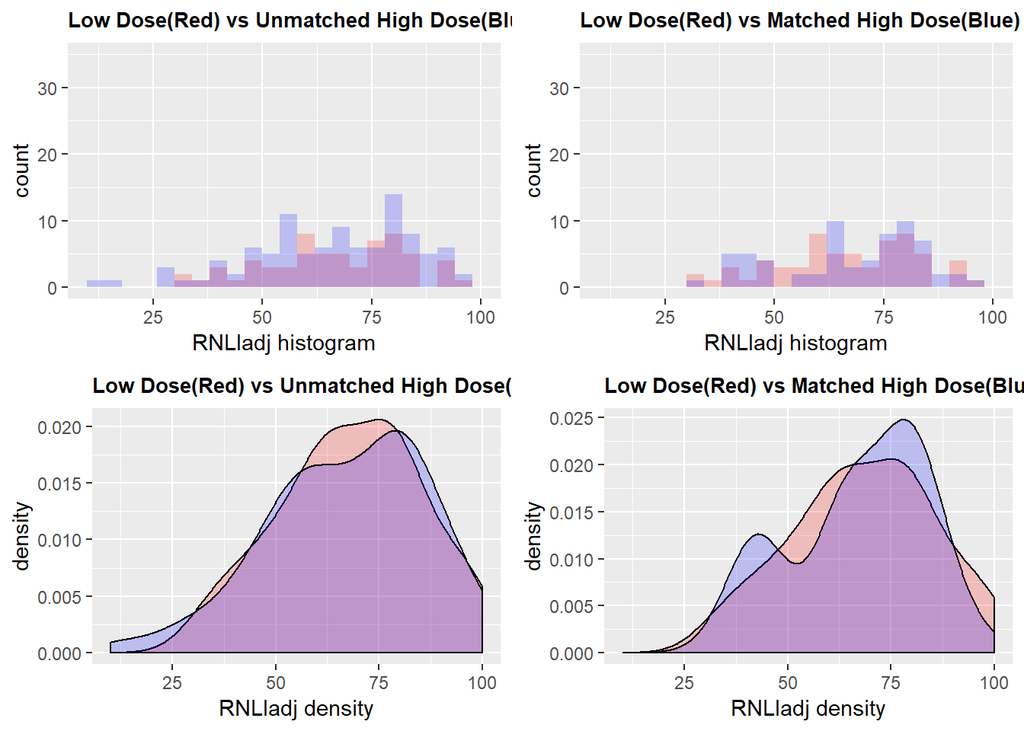

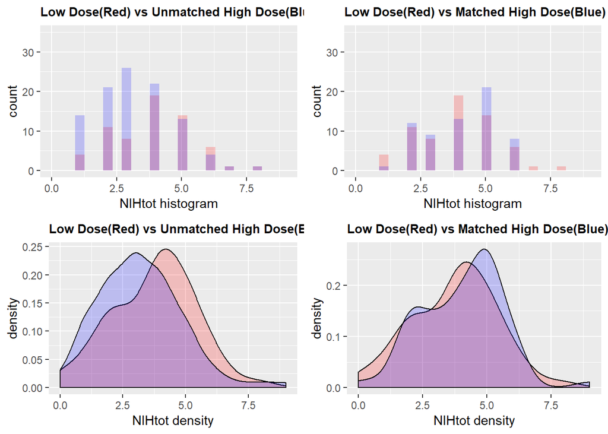

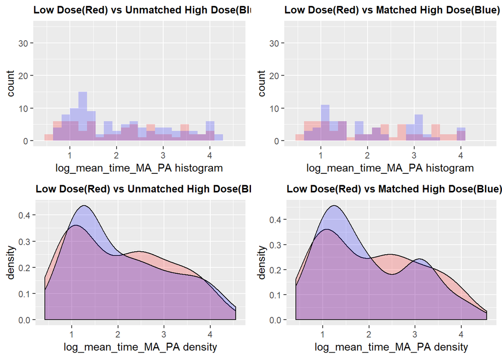

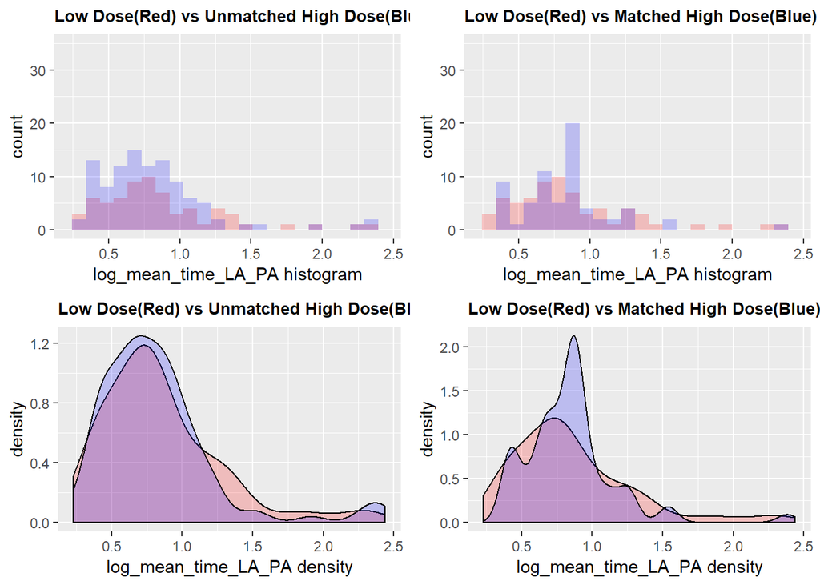

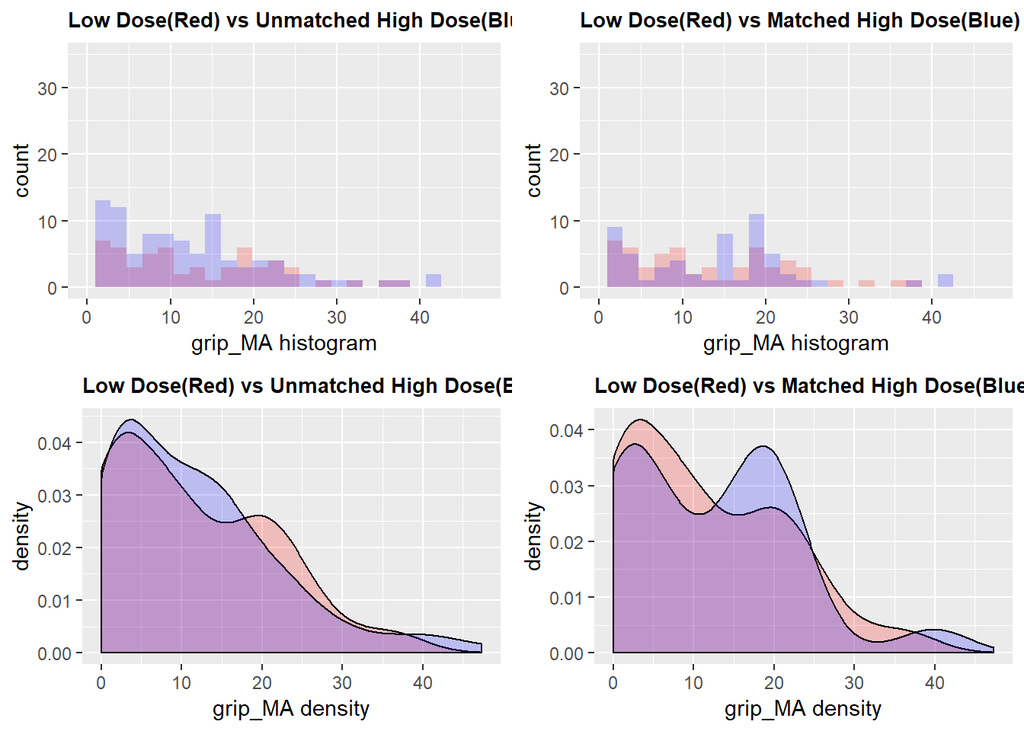

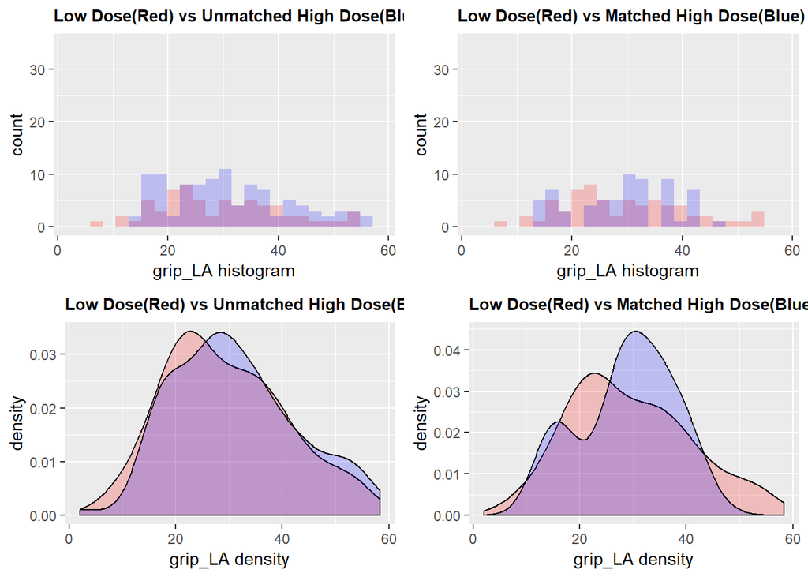

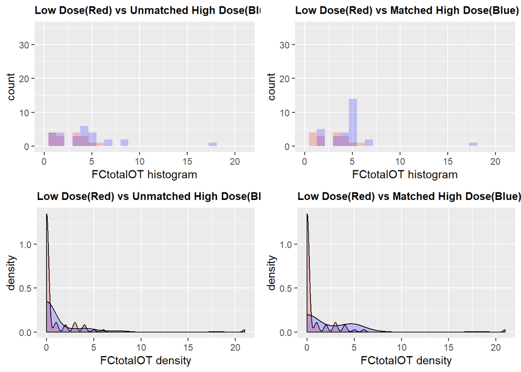

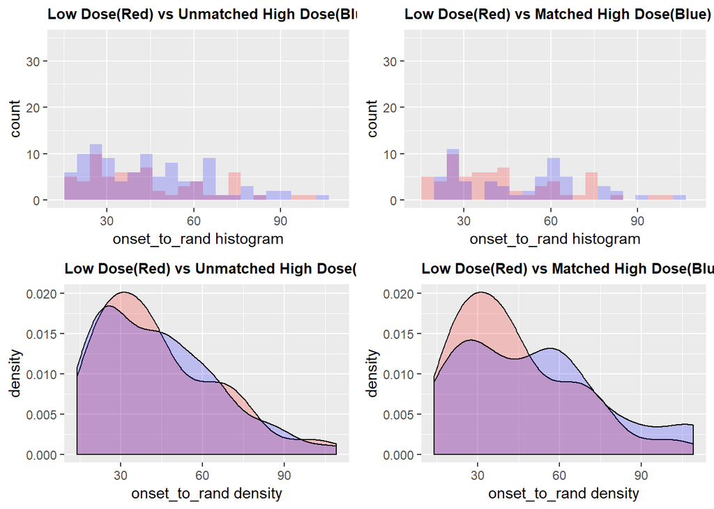

[2 more figures not shown]

```r
columns = colnames(data12)
for (i in c(2:11,13,15,17,20)){
  string= columns[i]

  b= max(data12[,i])/25

  plot1<-ggplot(data12, aes(eval(parse(text = string)))) +
    geom_histogram(data= data12[rr1$index.treated,],fill="red",alpha =0.2, binwidth=b)+
    geom_histogram(data= data12[-rr1$index.treated,],fill="blue",alpha =0.2, binwidth=b)+
    ggtitle("Low Dose(Red) vs Unmatched High Dose(Blue)")+
    theme(plot.title = element_text(face="bold", size=10)) +
    xlab(paste(string, "histogram"))+
    coord_cartesian(ylim=c(0,35))+
    xlim(min(data12[,i]),max(data12[,i]))

  plot2<- ggplot(data12, aes(eval(parse(text = string)))) +
    geom_histogram(data= data12[rr1$index.treated,],fill="red",alpha =0.2, binwidth=b)+
    geom_histogram(data= data12[rr1$index.control,],fill="blue",alpha =0.2, binwidth=b)+
    ggtitle("Low Dose(Red) vs Matched High Dose(Blue)")+
    theme(plot.title = element_text( face="bold", size=10)) +
    xlab(paste(string, "histogram"))+
    coord_cartesian(ylim=c(0,35))+
    xlim(min(data12[,i]),max(data12[,i]))

   plot3<-ggplot(data12, aes(eval(parse(text = string)))) +
    geom_density(data = data12[rr1$index.treated,],fill = "red", alpha = 0.2)+
    geom_density(data = data12[-rr1$index.treated,],fill = "blue", alpha = 0.2)+
    ggtitle("Low Dose(Red) vs Unmatched High Dose(Blue)")+
    theme(plot.title = element_text(face="bold", size=10)) +
    xlab(paste(string, "density"))+
    xlim(min(data12[,i]),max(data12[,i]))

   plot4<-ggplot(data12, aes(eval(parse(text = string)))) +
    geom_density(data = data12[rr1$index.treated,],fill = "red", alpha = 0.2)+
    geom_density(data = data12[rr1$index.control,],fill = "blue", alpha = 0.2)+
    ggtitle("Low Dose(Red) vs Matched High Dose(Blue)")+
    theme(plot.title = element_text(face="bold", size=10)) +
    xlab(paste(string, "density"))+
    xlim(min(data12[,i]),max(data12[,i]))

  grid.arrange(plot1, plot2, plot3, plot4, ncol=2, nrow=2)
}
```

### Genetic matching

This function finds optimal balance using multivariate matching where a genetic search algorithm determines the weight each covariate is given. Balance is determined by examining cumulative probability distribution functions of a variety of standardized statistics. By default, these statistics include t-tests and Kolmogorov-Smirnov tests. A variety of descriptive statistics based on empirical-QQ (eQQ) plots can also be used or any user provided measure of balance. The statistics are not used to conduct formal hypothesis tests, because no measure of balance is a monotonic function of bias and because balance should be maximized without limit. The object returned by GenMatch can be supplied to the Match function (via the Weight.matrix option) to obtain causal estimates. GenMatch uses **GENoud** to perform the genetic search.

- Tr= data12$treat A vector indicating the observations which are in the treatment regime and those which are not. This can either be a logical vector or a real vector where 0 denotes control and 1 denotes treatment.
- X=X A matrix containing the variables we wish to match on. #####This matrix may contain the actual observed covariates or the propensity score or a combination of both.
- pop.size= 10000 Population Size. This is the number of individuals genoud uses to solve the optimization problem. The theorems proving that genetic algorithms find good solutions are asymptotic in population size. Therefore, it is important that this value not be small. See genoud for more details.

**GENoud**- GENetic Optimization Using Derivatives Genoud is a function that combines evolutionary search algorithms with derivative-based (Newton or quasi-Newton) methods to solve difficult optimization problems.

```r
# Adding propensity score to estimation
X1 = cbind(X,data12$propensity.score)

gen1 = GenMatch(Tr= data12$treat, X=X1, pop.size=10000, replace=TRUE, max.weight=1);
```

```
##
##
## Tue Apr 30 21:21:43 2019
## Domains:
##  0.000000e+00   <=  X1   <=    1.000000e+00
##  0.000000e+00   <=  X2   <=    1.000000e+00
##  0.000000e+00   <=  X3   <=    1.000000e+00
##  0.000000e+00   <=  X4   <=    1.000000e+00
##  0.000000e+00   <=  X5   <=    1.000000e+00
##  0.000000e+00   <=  X6   <=    1.000000e+00
##  0.000000e+00   <=  X7   <=    1.000000e+00
##  0.000000e+00   <=  X8   <=    1.000000e+00
##  0.000000e+00   <=  X9   <=    1.000000e+00
##  0.000000e+00   <=  X10  <=    1.000000e+00
##  0.000000e+00   <=  X11  <=    1.000000e+00
##  0.000000e+00   <=  X12  <=    1.000000e+00
##  0.000000e+00   <=  X13  <=    1.000000e+00
##  0.000000e+00   <=  X14  <=    1.000000e+00
##  0.000000e+00   <=  X15  <=    1.000000e+00
##  0.000000e+00   <=  X16  <=    1.000000e+00
##  0.000000e+00   <=  X17  <=    1.000000e+00
##  0.000000e+00   <=  X18  <=    1.000000e+00
##  0.000000e+00   <=  X19  <=    1.000000e+00
##  0.000000e+00   <=  X20  <=    1.000000e+00
##  0.000000e+00   <=  X21  <=    1.000000e+00
##  0.000000e+00   <=  X22  <=    1.000000e+00
##  0.000000e+00   <=  X23  <=    1.000000e+00
##  0.000000e+00   <=  X24  <=    1.000000e+00
##  0.000000e+00   <=  X25  <=    1.000000e+00
##  0.000000e+00   <=  X26  <=    1.000000e+00
##  0.000000e+00   <=  X27  <=    1.000000e+00
##  0.000000e+00   <=  X28  <=    1.000000e+00
##  0.000000e+00   <=  X29  <=    1.000000e+00
##  0.000000e+00   <=  X30  <=    1.000000e+00
##  0.000000e+00   <=  X31  <=    1.000000e+00
##  0.000000e+00   <=  X32  <=    1.000000e+00
##  0.000000e+00   <=  X33  <=    1.000000e+00
##  0.000000e+00   <=  X34  <=    1.000000e+00
##  0.000000e+00   <=  X35  <=    1.000000e+00
##  0.000000e+00   <=  X36  <=    1.000000e+00
```

[output cut: 4324 more lines]

```
##  X[53] : 6.386914e-01
##  X[54] : 1.285294e-01
##  X[55] : 9.805647e-01
##  X[56] : 3.853347e-02
##  X[57] : 9.505070e-01
##  X[58] : 7.355239e-01
##  X[59] : 2.735479e-01
##  X[60] : 9.281609e-01
##  X[61] : 4.232836e-01
##
## Solution Found Generation 11
## Number of Generations Run 16
##
## Tue Apr 30 21:56:01 2019
## Total run time : 0 hours 34 minutes and 18 seconds
```

```r
mgen1=Match(Tr=data12$treat, X=X1, Weight.matrix = gen1);
```

```r
summary(mgen1)
```

```
##
## Estimate...  0
## SE.........  0
## T-stat.....  NaN
## p.val......  NA
##
## Original number of observations..............  171
## Original number of treated obs...............  66
## Matched number of observations...............  66
## Matched number of observations  (unweighted).  66
```

#### Assessing balance

```r
MatchBalance(treat~ ave_CAHM + SIS_hand + ufugm + NIHtot + log_mean_time_MA_PA +
               log_mean_time_LA_PA + EQ_index +grip_MA +grip_LA +RNLIadj+

               CSgender+ concordance +  onset_to_rand + CStpa + age_at_rand +
               FCtotalOT+ log2.A1EstVol+old_stroke +DEMOsmoke+ leukoaraiosis+ multlesions+

               Site.code.1+ Site.code.2+ Site.code.3+Site.code.4+
               Site.code.5+ Site.code.6+ Site.code.7+ predominant.AC1+ predominant.AC2 +
               predominant.AC3+ predominant.ACH +predominant.basilar+ predominant.IB+
               predominant.LS+ predominant.MC2+ predominant.MC3+ predominant.MC5+ predominant.PCA+
               predominant.vertebral +predominant.THP+ hispanic.latino+nonhispanic.latino+
               race.indeginous+ race.asian+ race.pacific+ race.africanam+ race.caucasian +
               race.other+ edu.underHS+ edu.someHS +edu.finishHS +edu.someCollege +
               edu.finishCollege +edu.finishMasters +edu.finishPHD+stroke.loc.RightH+
               stroke.loc.LeftH +stroke.loc.cerebellar +stroke.loc.brainstem,

               data= data12, match.out= mgen1, nboots=100)
```

```
##
## ***** (V1) ave_CAHM *****
##                        Before Matching        After Matching
## mean treatment........     45.479             45.479
## mean control..........     47.275             48.108
## std mean diff.........    -7.9062            -11.572
##
## mean raw eQQ diff.....     4.4857             3.8407
## med  raw eQQ diff.....          4                3.5
## max  raw eQQ diff.....         12                 10
##
## mean eCDF diff........   0.052639           0.052149
## med  eCDF diff........   0.042424           0.045455
## max  eCDF diff........    0.15022            0.12121
##
## var ratio (Tr/Co).....    0.86576             1.1208
## T-test p-value........    0.62565            0.29251
## KS Bootstrap p-value..        0.2               0.68
## KS Naive p-value......    0.31985            0.71737
## KS Statistic..........    0.15022            0.12121
##
##
## ***** (V2) SIS_hand *****
##                        Before Matching        After Matching
## mean treatment........      30.53              30.53
## mean control..........     34.571             31.591
## std mean diff.........    -18.731            -4.9159
##
## mean raw eQQ diff.....     5.2273             3.4848
## med  raw eQQ diff.....          5                  5
## max  raw eQQ diff.....         15                 10
##
## mean eCDF diff........    0.05573           0.037879
## med  eCDF diff........   0.051948           0.030303
## max  eCDF diff........    0.10303            0.13636
##
## var ratio (Tr/Co).....    0.73011             1.1039
## T-test p-value........    0.26639            0.71078
## KS Bootstrap p-value..       0.55                0.4
## KS Naive p-value......    0.78283            0.57146
```

[output cut: 1073 more lines]

```
## max  raw eQQ diff.....          0                  1
##
## mean eCDF diff........  0.0030303           0.015152
## med  eCDF diff........  0.0030303           0.015152
## max  eCDF diff........  0.0060606           0.030303
##
## var ratio (Tr/Co).....    0.92022             1.9375
## T-test p-value........     0.8748            0.15576
##
##
## Before Matching Minimum p.value: 0.01
## Variable Name(s): NIHtot  Number(s): 4
##
## After Matching Minimum p.value: 0.07
## Variable Name(s): ufugm  Number(s): 3
```

### Checking number of unique subjects after genetic matching

```r
length(unique(mgen1$index.treated))
```

```
## [1] 66
```

```r
length(unique(mgen1$index.control))
```

```
## [1] 40
```

```r
(bal.tab(mgen1, treat~ ave_CAHM + SIS_hand + ufugm + NIHtot + log_mean_time_MA_PA +
               log_mean_time_LA_PA + EQ_index +grip_MA +grip_LA +RNLIadj+

               CSgender+ concordance +  onset_to_rand + CStpa + age_at_rand +
               FCtotalOT+ log2.A1EstVol+old_stroke +DEMOsmoke+ leukoaraiosis+ multlesions+

               Site.code.1+ Site.code.2+ Site.code.3+Site.code.4+
               Site.code.5+ Site.code.6+ Site.code.7+ predominant.AC1+ predominant.AC2 +
               predominant.AC3+ predominant.ACH +predominant.basilar+ predominant.IB+
               predominant.LS+ predominant.MC2+ predominant.MC3+ predominant.MC5+ predominant.PCA+
               predominant.vertebral +predominant.THP+ hispanic.latino+nonhispanic.latino+
               race.indeginous+ race.asian+ race.pacific+ race.africanam+ race.caucasian +
               race.other+ edu.underHS+ edu.someHS +edu.finishHS +edu.someCollege +
               edu.finishCollege +edu.finishMasters +edu.finishPHD+stroke.loc.RightH+
               stroke.loc.LeftH +stroke.loc.cerebellar +stroke.loc.brainstem+ propensity.score,

         disp.v.ratio = TRUE, data = data12,abs= TRUE, m.threshold =0.1))
```

```
## Balance Measures
##                          Type Diff.Adj        M.Threshold V.Ratio.Adj
## ave_CAHM              Contin.   0.2349 Not Balanced, >0.1      1.0268
## SIS_hand              Contin.   0.2999 Not Balanced, >0.1      1.2817
## ufugm                 Contin.   0.0223     Balanced, <0.1      1.0588
## NIHtot                Contin.   0.1549 Not Balanced, >0.1      1.2368
## log_mean_time_MA_PA   Contin.   0.1697 Not Balanced, >0.1      1.1240
## log_mean_time_LA_PA   Contin.   0.1798 Not Balanced, >0.1      1.6827
## EQ_index              Contin.   0.0159     Balanced, <0.1      1.3587
## grip_MA               Contin.   0.1760 Not Balanced, >0.1      1.1429
## grip_LA               Contin.   0.1892 Not Balanced, >0.1      1.0870
## RNLIadj               Contin.   0.0605     Balanced, <0.1      1.0453
## CSgender_2             Binary   0.1657 Not Balanced, >0.1
## concordance_2          Binary   0.1426 Not Balanced, >0.1
## onset_to_rand         Contin.   0.1278 Not Balanced, >0.1      1.2434
## CStpa                  Binary   0.0914     Balanced, <0.1
## age_at_rand           Contin.   0.0806     Balanced, <0.1      1.1093
## FCtotalOT             Contin.   0.0298     Balanced, <0.1      1.3149
## log2.A1EstVol         Contin.   0.1886 Not Balanced, >0.1      1.0254
## old_stroke             Binary   0.1493 Not Balanced, >0.1
## DEMOsmoke              Binary   0.1294 Not Balanced, >0.1
## leukoaraiosis          Binary   0.0654     Balanced, <0.1
## multlesions            Binary   0.0936     Balanced, <0.1
## Site.code.1            Binary   0.1350 Not Balanced, >0.1
## Site.code.2            Binary   0.1203 Not Balanced, >0.1
## Site.code.3            Binary   0.2372 Not Balanced, >0.1
## Site.code.4            Binary   0.1793 Not Balanced, >0.1
## Site.code.5            Binary   0.0871     Balanced, <0.1
## Site.code.6            Binary   0.2152 Not Balanced, >0.1
## Site.code.7            Binary   0.0652     Balanced, <0.1
## predominant.AC1        Binary   0.0000     Balanced, <0.1
## predominant.AC2        Binary   0.2638 Not Balanced, >0.1
## predominant.ACH        Binary   0.1252 Not Balanced, >0.1
## predominant.basilar    Binary   0.2660 Not Balanced, >0.1
## predominant.IB         Binary   0.1258 Not Balanced, >0.1
## predominant.LS         Binary   0.0100     Balanced, <0.1
## predominant.MC2        Binary   0.2016 Not Balanced, >0.1
## predominant.MC3        Binary   0.0572     Balanced, <0.1
## predominant.MC5        Binary   0.0457     Balanced, <0.1
## predominant.PCA        Binary
```

[output cut: 23 more lines]

```
## Balance tally for mean differences
##                    count
## Balanced, <0.1        27
## Not Balanced, >0.1    31
##
## Variable with the greatest mean difference
##          Variable Diff.Adj        M.Threshold
##  propensity.score   0.7809 Not Balanced, >0.1
##
## Sample sizes
##                      Control Treated
## All                      105      66
## Matched                  105      66
## Matched (Unweighted)      72      66
## Unmatched                 33       0
```

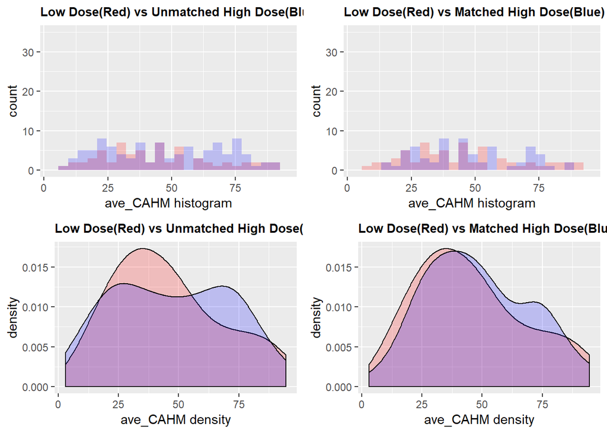

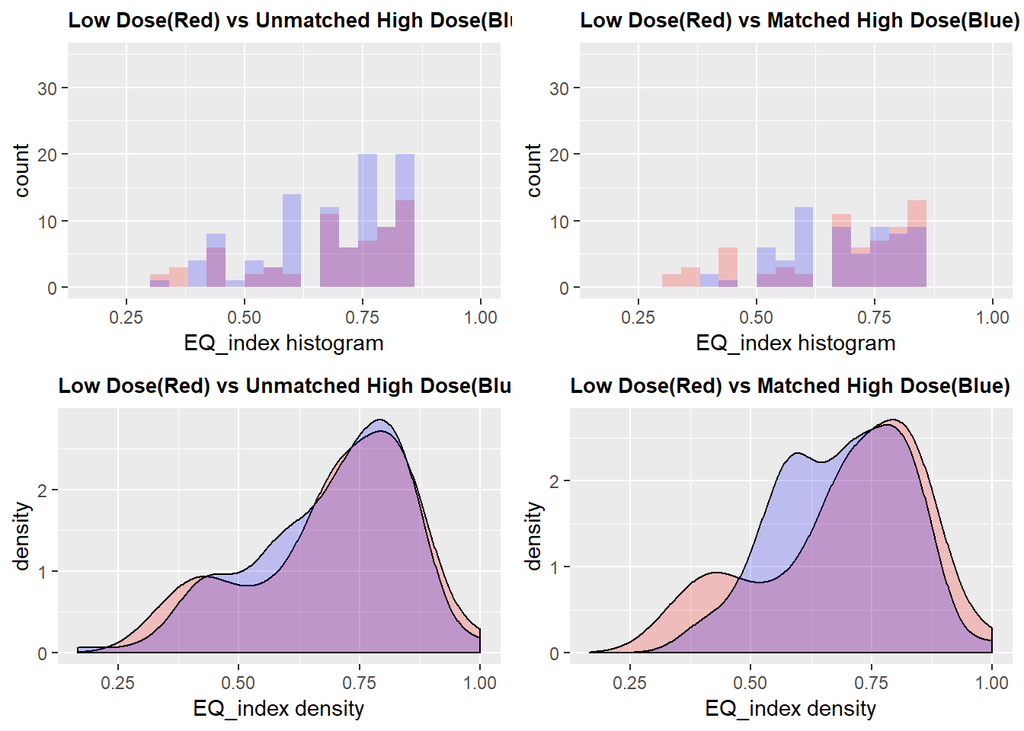

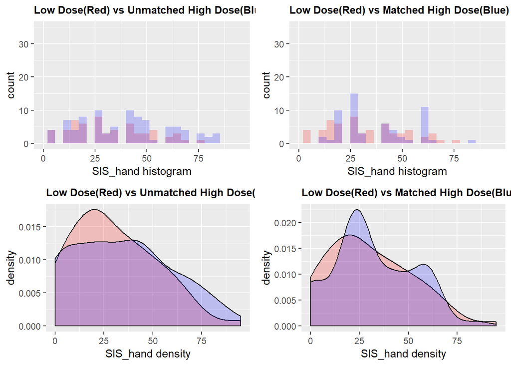

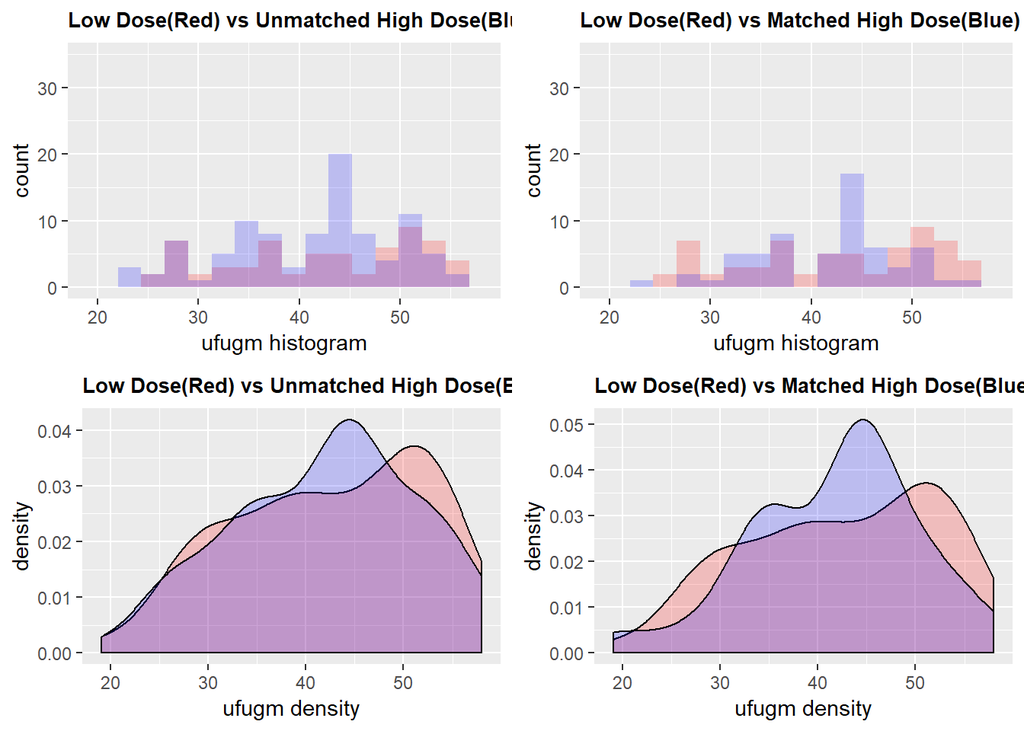

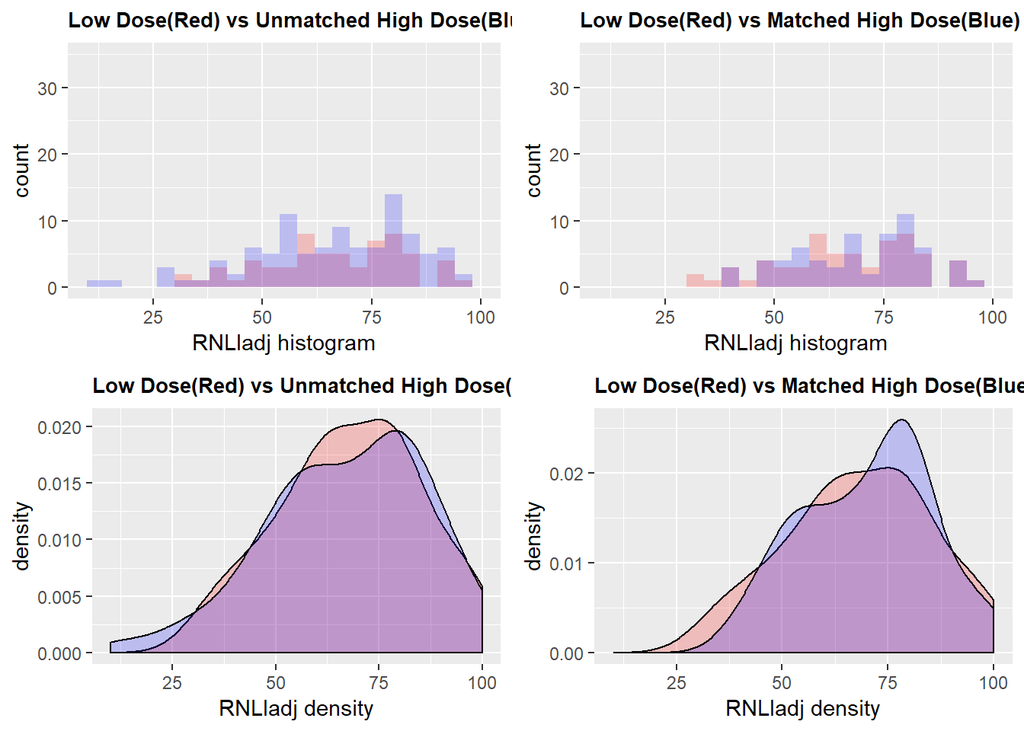

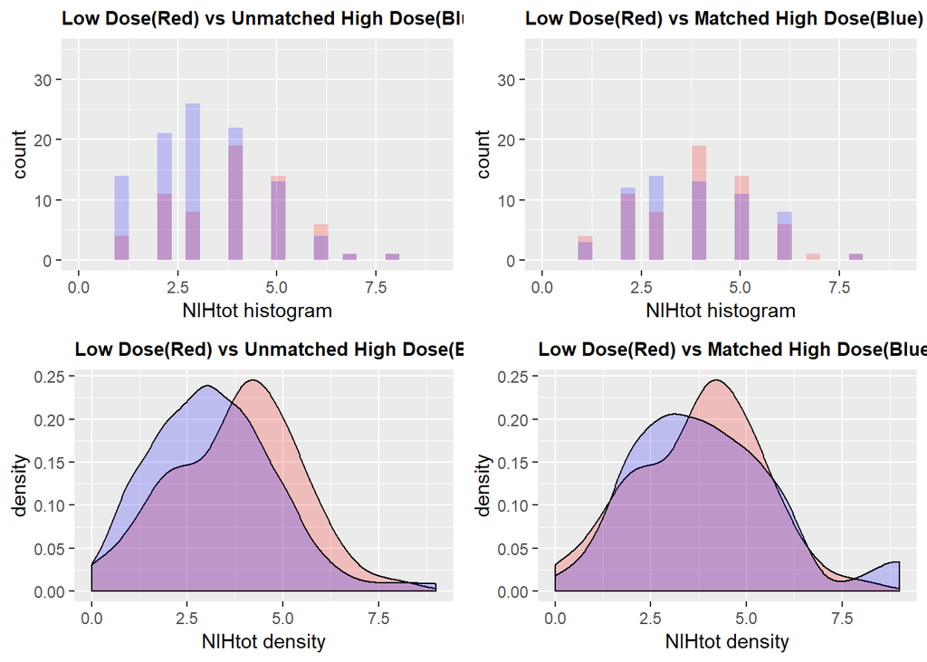

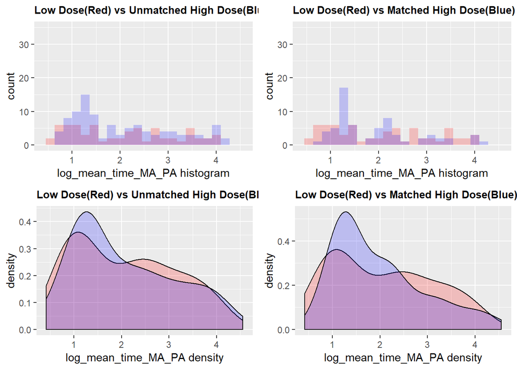

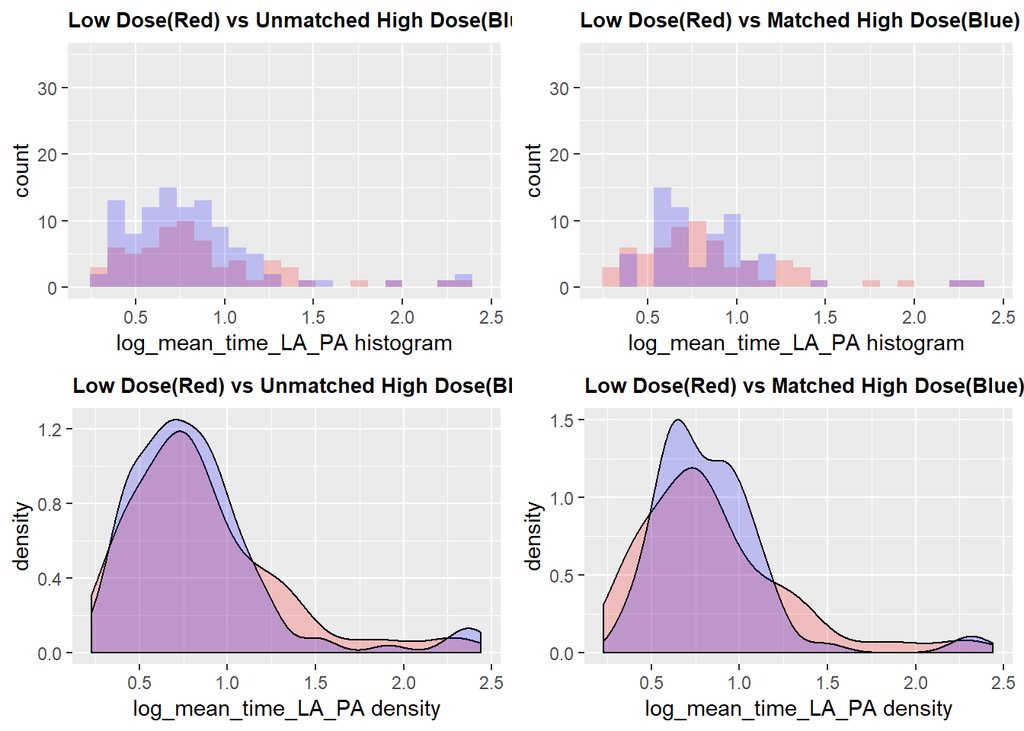

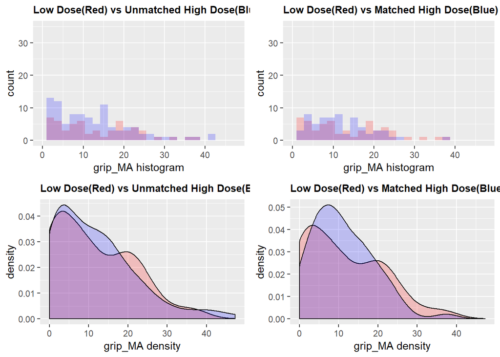

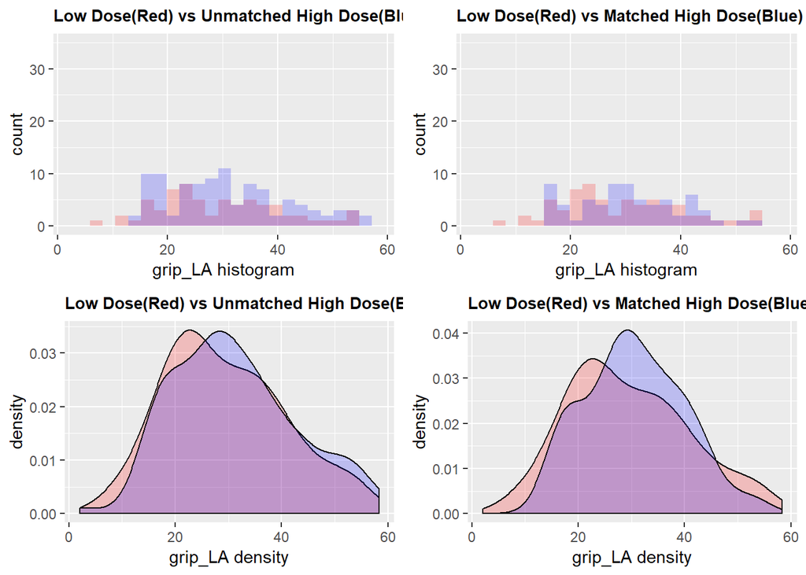

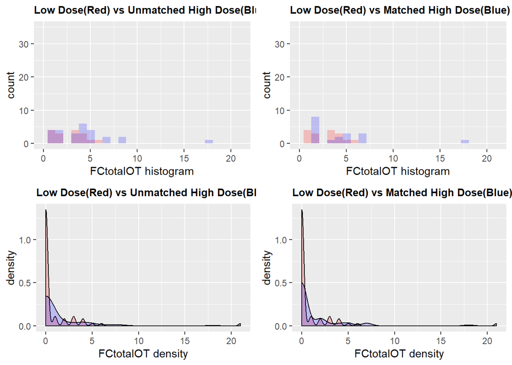

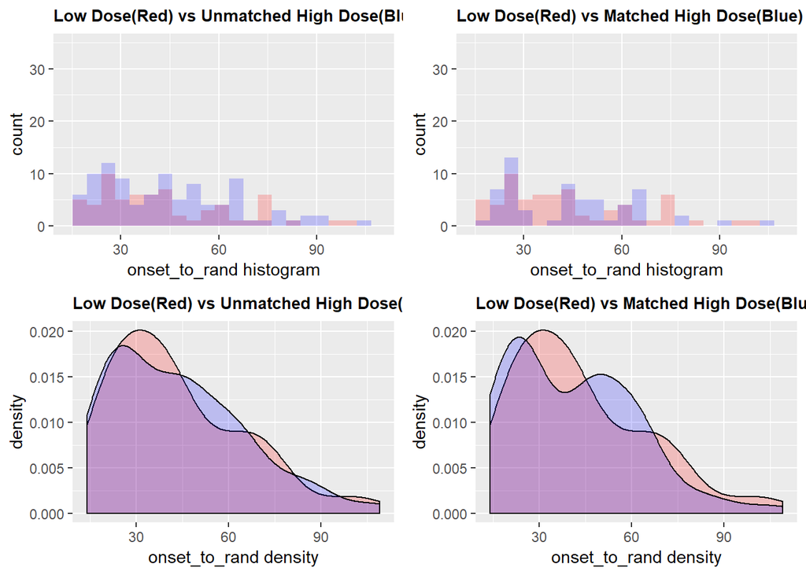

[2 more figures not shown]

```r
columns = colnames(data12)
for (i in c(2:11,13,15,17,20)){
  string= columns[i]

  b= max(data12[,i])/25

  plot1<-ggplot(data12, aes(eval(parse(text = string)))) +
    geom_histogram(data= data12[mgen1$index.treated,],fill="red",alpha =0.2, binwidth=b)+
    geom_histogram(data= data12[-mgen1$index.treated,],fill="blue",alpha =0.2, binwidth=b)+
    ggtitle("Low Dose(Red) vs Unmatched High Dose(Blue)")+
    theme(plot.title = element_text(face="bold", size=10)) +
    xlab(paste(string, "histogram"))+
    coord_cartesian(ylim=c(0,35))+
    xlim(min(data12[,i]),max(data12[,i]))

  plot2<- ggplot(data12, aes(eval(parse(text = string)))) +
    geom_histogram(data= data12[mgen1$index.treated,],fill="red",alpha =0.2, binwidth=b)+
    geom_histogram(data= data12[mgen1$index.control,],fill="blue",alpha =0.2, binwidth=b)+
    ggtitle("Low Dose(Red) vs Matched High Dose(Blue)")+
    theme(plot.title = element_text( face="bold", size=10)) +
    xlab(paste(string, "histogram"))+
    coord_cartesian(ylim=c(0,35))+
    xlim(min(data12[,i]),max(data12[,i]))

   plot3<-ggplot(data12, aes(eval(parse(text = string)))) +
    geom_density(data = data12[mgen1$index.treated,],fill = "red", alpha = 0.2)+
    geom_density(data = data12[-mgen1$index.treated,],fill = "blue", alpha = 0.2)+
    ggtitle("Low Dose(Red) vs Unmatched High Dose(Blue)")+
    theme(plot.title = element_text(face="bold", size=10)) +
    xlab(paste(string, "density"))+
    xlim(min(data12[,i]),max(data12[,i]))

   plot4<-ggplot(data12, aes(eval(parse(text = string)))) +
    geom_density(data = data12[mgen1$index.treated,],fill = "red", alpha = 0.2)+
    geom_density(data = data12[mgen1$index.control,],fill = "blue", alpha = 0.2)+
    ggtitle("Low Dose(Red) vs Matched High Dose(Blue)")+
    theme(plot.title = element_text(face="bold", size=10)) +
    xlab(paste(string, "density"))+
    xlim(min(data12[,i]),max(data12[,i]))

  grid.arrange(plot1, plot2, plot3, plot4, ncol=2, nrow=2)
}
```